# Assignment 7 - Repeated measure

Author

COMFORT ADEGBENRO

# 1 Introduction

This assignment will ask you to conduct a repeated measure analysis.

For that, you will first need to watch (and code along with) the following repeated measure video:

- repeated measure lecture: https://youtu.be/-ANqcQhB–A?si=7YeeYqDgcLsj5erW&t=4268 (starts at 01:11:08, watch till the end, about 50 min)
- repeated measure lab part 1: https://youtu.be/GY2e-9M5bFM?si=TIw5F4EF2m9Dx5uK (watch full video, ~1h 50 min)
- repeated measure lab part 2: https://youtu.be/F3vg89ymLeM?si=Zv-RPIdS8mig4EMb (watch full video, ~2h)
- The partial script for the video above is in our GitHub repository, 04-classcode, **03-11_repeatedmeasure_partial.qmd**.
- The data set for this exercise is in oir GitHub repository, 03-classcode, **wheat_nk_balkh_rm.csv**.

**AFTER watching the video and developing the code in class**, then start working on this HW assignment.

# 2 Instructions

- Create on your GitHub a repo named `06_rm`.
- Clone it to your computer, create the necessary subfolders.
- Move the script **03-11_repeatedmeasure_partial.qmd** into the `code` subfolder.
- Move this script into the `code` subfolder
- Move the **wheat_nk_balkh_rm.csv** data set into the `data` subfolder
- On this script, fill your name under the `title` section of the YAML

# 3 Goal of this assignment

The goal is this assignment is for you to **learn about and conduct a full repeated measure analysis**.

Once you finish coding along with the videos, answer the following questions.

# 4 Questions

In class, we decided to use AIC as the metric to select the best model, and this determined the best model to be the one with a general error correlation matrix structure. If we had used BIC as the metric, then the model selected would have been the default model. Here, you are asked to use BIC and thus select the default model as the best, and perform all the steps after model selection. You may copy and paste the class script, and adapt the copied version to implement these changes.

## 4.1 Q1: Include here the residual assessment of the default model. Include each plot and its interpretation. How do these residuals from the default model visually compare to those from the general model?

```r
library(tidyverse) # for data wrangling and plotting
library(car) # for Anova function
library(broom.mixed)
library(lme4)
library(broom) # for model residuals extraction
library(emmeans) # for model mean extraction
library(multcomp) # for pairwise comparison letter display
library(nlme) # for repeated measure correlation structures
```

```r
rm_rcbd_df = read_csv("../data/wheat_nk_balkh_rm.csv") %>%
  mutate(across(trt:splot, ~factor(.))) %>%
  mutate(fdap = factor(dap))

head(rm_rcbd_df)
```

```
# A tibble: 6 × 10
  trt   block nrate_kgha krate_kgha trtname wplot splot yield_kgha   dap fdap
  <fct> <fct> <fct>      <fct>      <fct>   <fct> <fct>      <dbl> <dbl> <fct>
1 1     1     0          0          0+0     101   101-1       5488   120 120
2 1     1     0          0          0+0     101   101-1       5898   130 130
3 1     1     0          0          0+0     101   101-1       6133   140 140
4 1     1     0          0          0+0     101   101-1       6151   150 150
5 2     1     0          30         0+30    102   102-1       4448   120 120
6 2     1     0          30         0+30    102   102-1       4842   130 130
```

```r
summary(rm_rcbd_df)
```

```
      trt     block  nrate_kgha krate_kgha    trtname       wplot
 1      :16   1:36   0  :48     0 :48      0+0    :16   101    :12
 2      :16   2:36   100:48     30:48      0+30   :16   102    :12
 3      :16   3:36   200:48     60:48      0+60   :16   103    :12
 4      :16   4:36                         100+0  :16   201    :12
 5      :16                                100+30 :16   202    :12
 6      :16                                100+60 :16   203    :12
 (Other):48                                (Other):48   (Other):72
     splot       yield_kgha        dap         fdap
 101-1  :  4   Min.   :2795   Min.   :120.0   120:36
 101-2  :  4   1st Qu.:4788   1st Qu.:127.5   130:36
 101-3  :  4   Median :5280   Median :135.0   140:36
 102-1  :  4   Mean   :5233   Mean   :135.0   150:36
 102-2  :  4   3rd Qu.:5782   3rd Qu.:142.5
 102-3  :  4   Max.   :8121   Max.   :150.0
 (Other):120
```

```r
options(contrasts = c("contr.sum", "contr.poly"))

mod1_default = lme(yield_kgha ~ krate_kgha*nrate_kgha*fdap,
                   random = ~ 1 | block/krate_kgha/nrate_kgha,
                   data = rm_rcbd_df)
```

```r
mod1_default_resid <- augment(mod1_default) %>%
  mutate(.stdresid=resid(mod1_default, type="pearson", scaled=T))

head(mod1_default_resid)
```

```
# A tibble: 6 × 14
  trt   block nrate_kgha krate_kgha trtname wplot splot yield_kgha   dap fdap
  <fct> <fct> <fct>      <fct>      <fct>   <fct> <fct>      <dbl> <dbl> <fct>
1 1     1     0          0          0+0     101   101-1       5488   120 120
2 1     1     0          0          0+0     101   101-1       5898   130 130
3 1     1     0          0          0+0     101   101-1       6133   140 140
4 1     1     0          0          0+0     101   101-1       6151   150 150
5 2     1     0          30         0+30    102   102-1       4448   120 120
6 2     1     0          30         0+30    102   102-1       4842   130 130
# ℹ 4 more variables: .fitted <dbl>, .resid <dbl>, .fixed <dbl>,
#   .stdresid <dbl>
```

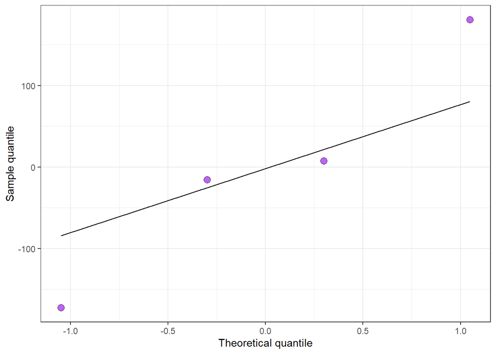

```r
ranef(mod1_default)[[1]] %>%
  ggplot(aes(sample=`(Intercept)`))+
  stat_qq(  shape = 21,
            fill = "purple",
            size = 3,
            alpha = .7
  )+
  stat_qq_line()+
  labs(x = "Theoretical quantile",
       y = "Sample quantile")+
  theme_bw()
```

The distribution of the block random effect looks normal and is comparable to the general model plot.

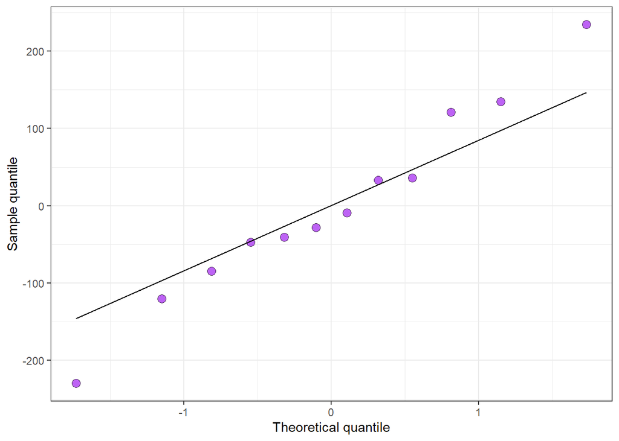

```r
ranef(mod1_default)[[2]] %>%
  ggplot(aes(sample=`(Intercept)`))+
  stat_qq(  shape = 21,
            fill = "purple",
            size = 3,
            alpha = .7
  )+
  stat_qq_line()+
  labs(x = "Theoretical quantile",
       y = "Sample quantile")+
  theme_bw()
```

Similarly, the distribution of the block by k rate random effect looks normal and is comparable to the general model plot.

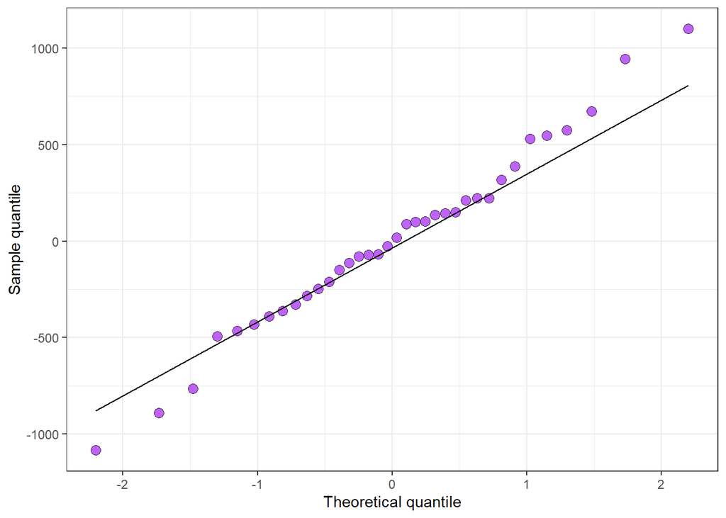

```r
ranef(mod1_default)[[3]] %>%
  ggplot(aes(sample=`(Intercept)`))+
  stat_qq(  shape = 21,
            fill = "purple",
            size = 3,
            alpha = .7
  )+
  stat_qq_line()+
  labs(x = "Theoretical quantile",
       y = "Sample quantile")+
  theme_bw()
```

The qq plot for the block by k rate by n rate random effect shows that they are normally distributed, independent and homogeneous, though some deviations can be seen at the tails. This plot is comparable to that of the general model.

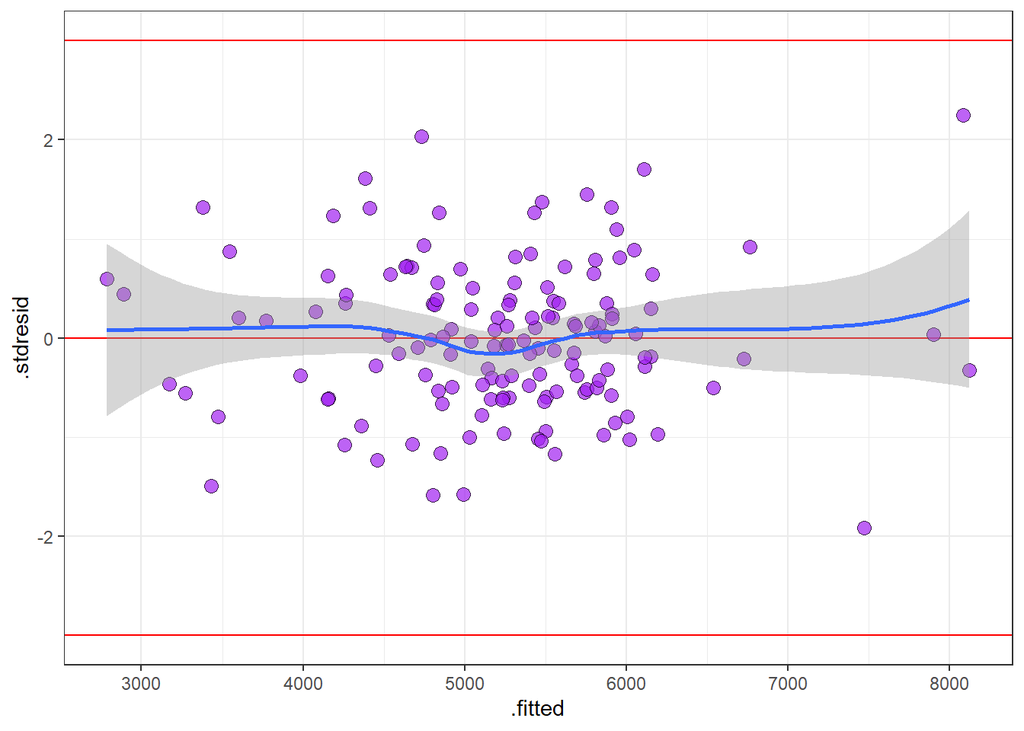

```r
ggplot(mod1_default_resid, aes(x=.fitted, y=.stdresid))+
  geom_hline(yintercept = 0, color="red")+
  geom_point(shape = 21,
             fill = "purple",
             size = 3,
             alpha = .7)+
  geom_smooth()+
  geom_hline(yintercept = c(-3,3), color = "red")+
  theme_bw()
```

The residuals appear to be homogeneous with no patterns observed indicating independence. Additionally as all the points fall within the -3 and +3 mark, there are no outliers. This plot looks similar to the general model selected from AIC, however, the smooth line around the zero appears to be sitting better on the zero mark compared to the general model.

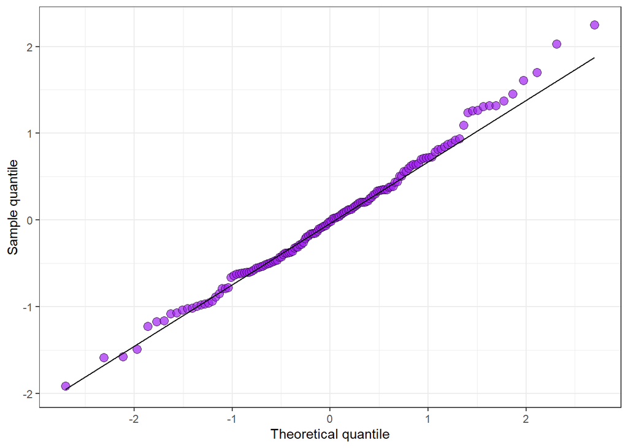

```r
ggplot(mod1_default_resid, aes(sample=.stdresid))+
  stat_qq(  shape = 21,
            fill = "purple",
            size = 3,
            alpha = .7
  )+
  stat_qq_line()+
  labs(x = "Theoretical quantile",
       y = "Sample quantile")+
  theme_bw()
```

The residuals are normally distributed, but comparing this plot to that of the general model, there seems to be less deviation at the tail, suggesting the distribution normality might be better.

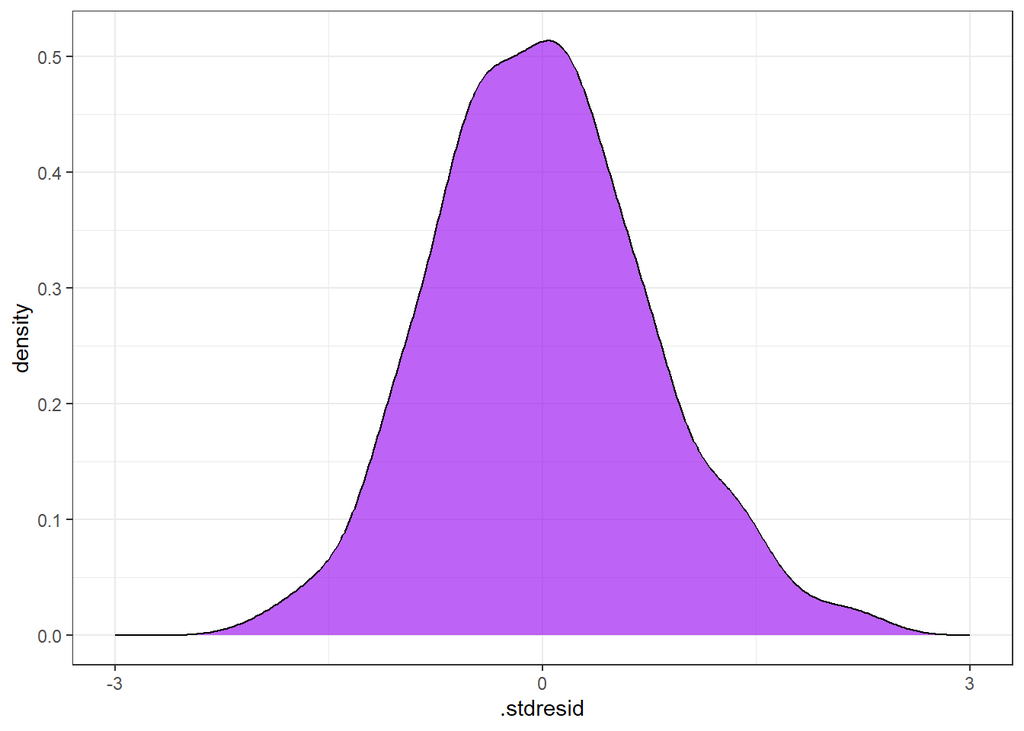

```r
ggplot(mod1_default_resid, aes(x=.stdresid))+
  geom_density(color = "black",
               fill = "purple",
               alpha = .7)+
  scale_x_continuous(breaks = c(-3,0,3), limits = c(-3,3))+
  theme_bw()
```

The density plot equally confirms that the residuals from the default model are normally distributed. However, comparing to the general model, the peak is higher, suggesting that more of the residuals are centered around zero and less variability.

## 4.2 Q2: Include here the ANOVA table from the default model. How does it compare with the ANOVA table from the general model?

```r
Anova(mod1_default, type = 3)
```

```
Analysis of Deviance Table (Type III tests)

Response: yield_kgha
                                Chisq Df Pr(>Chisq)
(Intercept)                 1040.2045  1  < 2.2e-16 ***
krate_kgha                     0.9113  2    0.63404
nrate_kgha                     4.5157  2    0.10458
fdap                       44330.3542  3  < 2.2e-16 ***
krate_kgha:nrate_kgha         33.2786  4  1.047e-06 ***
krate_kgha:fdap                3.7507  6    0.71038
nrate_kgha:fdap                3.1727  6    0.78688
krate_kgha:nrate_kgha:fdap    19.8741 12    0.06951 .
---
Signif. codes:  0 '***' 0.001 '**' 0.01 '*' 0.05 '.' 0.1 ' ' 1
```

Results of the ANOVA are quite different from the first (general) model. For the general model, in addition to harvesting date, and interaction between k rate and n rate, there was a significant interaction between all three treatment factors. Meanwhile, the default model did not show this interaction between the three factors as being statistically significant at a p-value of 0.05.

```r
rm_rcbd_cld_kndap1 <- emmeans(mod1_default, ~nrate_kgha:krate_kgha) %>%
  cld(reversed = T,
      Letters = letters,
      adjust = "none"
      ) %>%
  as.data.frame() %>%
  mutate(letter = trimws(.group)) %>%
  mutate(trtname = paste0(nrate_kgha,"+",krate_kgha))

rm_rcbd_cld_kndap1
```

```
  nrate_kgha krate_kgha   emmean       SE df lower.CL upper.CL .group letter
2          0         60 6381.875 334.6113  3 5316.993 7446.757   a         a
9          0          0 5559.812 334.6113  3 4494.930 6624.695   abc     abc
4        200         30 5513.687 334.6113  3 4448.805 6578.570   ab       ab
8        100         30 5485.062 334.6113  3 4420.180 6549.945   ab       ab
3        200          0 5412.500 334.6113  3 4347.618 6477.382   abc     abc
5        100         60 5294.125 334.6113  3 4229.243 6359.007    bcd    bcd
6          0         30 4618.375 334.6113  3 3553.493 5683.257     cd     cd
1        200         60 4483.625 334.6113  3 3418.743 5548.507    bcd    bcd
7        100          0 4352.312 334.6113  3 3287.430 5417.195      d      d
  trtname
2    0+60
9     0+0
4  200+30
8  100+30
3   200+0
5  100+60
6    0+30
1  200+60
7   100+0
```

Means were extracted for the significant n rate by k rate interaction.

```r
rm_rcbd_cld_kndap2 <- emmeans(mod1_default, ~fdap) %>%
  cld(reversed = T,
      Letters = letters,
      adjust = "none"
      ) %>%
  as.data.frame() %>%
  mutate(letter = trimws(.group))

rm_rcbd_cld_kndap2
```

```
  fdap   emmean       SE df lower.CL upper.CL .group letter
1  150 5471.639 162.2812  3 4955.188 5988.090   a         a
2  140 5420.250 162.2812  3 4903.799 5936.701    b        b
3  130 5220.722 162.2812  3 4704.271 5737.173     c       c
4  120 4821.333 162.2812  3 4304.882 5337.785      d      d
```

Means were also extracted and compared for the harvest date.

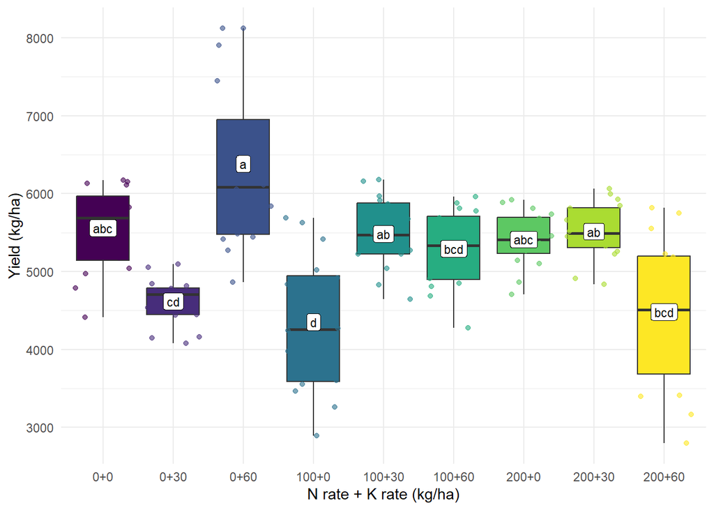

```r
ggplot() +
  geom_boxplot(data = rm_rcbd_df,
               aes(x = trtname,
                   y = yield_kgha,
                   fill = trtname)) +
  geom_jitter(data = rm_rcbd_df,
              aes(x = trtname, y = yield_kgha,
                  color = trtname),
              alpha = 0.6) +
  geom_label(data = rm_rcbd_cld_kndap1,
            aes(x = trtname,
                y = emmean,
                label = letter),
            size = 3) +
  labs(x = "N rate + K rate (kg/ha)",
       y = "Yield (kg/ha)") +
  scale_fill_viridis_d() +
  scale_color_viridis_d() +
  theme_minimal() +
  theme(legend.position = "none")
```

```r
ggsave("../output/k_nrate.png",
       height = 4,
       width = 6)
```

From the pairwise comparison and the above boxplot, to improve yield, the best performing n rate by k rate combinations (sharing the same letter) were: 0+60, 0+0, 100+30, 200+0, and 200+30 nrate + krate combinations. Although some of these would be considered to be at the same level with other treatment combinations. Lastly, the lowest performing combinations were: 100+0, 0+30 100+60 and 200+60 nrate + krate combinations.

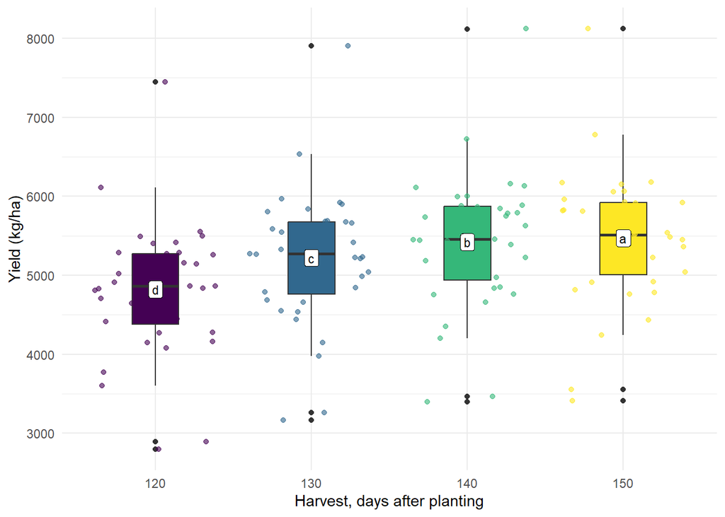

```r
ggplot() +
  geom_boxplot(data = rm_rcbd_df,
               aes(x = fdap,
                   y = yield_kgha,
                   fill = fdap
                   ), width = 0.3) +
  geom_jitter(data = rm_rcbd_df,
              aes(x = fdap, y = yield_kgha,
                  color = fdap),
              alpha = 0.6) +
  geom_label(data = rm_rcbd_cld_kndap2,
            aes(x = fdap,
                y = emmean,
                label = letter),
            size = 3) +
  labs(x = "Harvest, days after planting",
       y = "Yield (kg/ha)") +
  scale_fill_viridis_d() +
  scale_color_viridis_d() +
  theme_minimal() +
  theme(legend.position = "none")
```

```r
ggsave("../output/fdap.png",
       height = 4,
       width = 6)
```

Pairwise comparison showed that harvesting at 150 days after planting resulted in the higher yield. Additionally, the result showed that as days after planting increased, the yield in kg/ha equally increased. This was comparable to the general model.

# 5 Submitting your work

Once you have developed all the code and answers, make sure to Render this quarto file.

**Notes on rendering**:

- Make sure to render your work and inspect how the final html look like.
- If it does not look professional for whatever reason, then fix the issue, re-render it, recheck.
- Only send me your work once your html file looks professional.
  - **DO NOT** delete the file’s heading levels (# and ##). They set up the proper heading 1 and 2 levels, and I use them to guide my grading.
  - If a given chunk is also outputting warnings or messages, inhibit this behavior by changing the chunk options `message` and `warning` to `FALSE` (I’ll demo this in a moment).
  - If, after rendered, 2 lines of text are connected and you wish to “break line” between them, add 2 extra spaces after the first one (I’lld demo this in a moment).

After rendering, an .html file will be created on your `code` folder.

Rename this file to `Assignment-07-rm-LASTNAME.html`.

For ex., mine would be `Assignment-07-rm-Bastos.html`.

Submit your work by uploading the **html** file to **eLC Assigment #7 - Repeated measure** by Mar 25 11:59 pm.